# Programming with models: Inspecting model structure

BYU Summer Institute on Applied Statistics workshop

NIMBLE Development Team

# Running example: the AFT model

Now let’s explore how to understand the dependence structure of a model. After all the model is a directed acyclic graph, so we should be able to work with that graph structure.

We’ll demo this using the AFT survival model from the example models. I’ll make a slight tweak to the model and use a multivariate normal prior distribution for *delta* in order to illustrate some additional concepts.

We first need to build the model.

```r
codeAFT <- nimbleCode({
    for(i in 1:n) {
        x[i] ~ dweib(alpha, lambda[i])
        is_cens[i] ~ dinterval(x[i], c[i])  ## right-censoring
        lambda[i] <- exp(eta + inprod(Z[i,1:p], delta[1:p]))
    }
    eta ~ dunif(b0, B0) ## base measure H_b
    alpha ~ dunif(a0, A0)
    delta[1:p] ~ dmnorm(mu[1:p], cov = Sigma[1:p, 1:p])
})
```

```r
library(emplik, quietly = TRUE, warn.conflicts = FALSE)
data(myeloma)

n <- nrow(myeloma)
time <-  myeloma[ , 1]    ## survival or censoring time
vstatus <- myeloma[ , 2]  ##  0 = alive (i.e., censored)
alive <- vstatus == 0
cens_time <- rep(NA, n)
cens_time[alive] <- time[alive]
cens_time[!alive] <- Inf
time[alive] <- NA
## covariates:
logBUN <- myeloma[ , 3]
HGB <- myeloma[ , 4]
logBUN <- (logBUN - mean(logBUN)) / sd(logBUN)
HGB <- (HGB - mean(HGB)) / sd(HGB)

nSub = 15
constants = list(b0 = -10, B0 = 10, a0 = 0.1, A0 = 10, p = 2, n = n,
                 c = cens_time, Z = cbind(logBUN, HGB), nSub = nSub,
                 mu = rep(0, 2), Sigma = diag(2))
data = list(is_cens = as.numeric(alive), x = time)
xInit <- rep(NA, n)
xInit[alive] <- cens_time[alive] + 10
inits = list(alpha = 1, delta = c(0, 0), eta = 1, x = xInit)
model <- nimbleModel(codeAFT, constants = constants, data = data, inits = inits)
```

```
## defining model...
```

```
## Adding Z,mu,Sigma as data for building model.
```

```
## building model...
```

```
## setting data and initial values...
```

```
## running calculate on model (any error reports that follow may simply reflect missing values in model variables) ...
## checking model sizes and dimensions...
## model building finished.
```

# Nodes and variables

Note, if we have a multivariate distribution, then the node includes all of the elements: `delta[1:2]` is the node and `delta` is the variable.

# Querying nodes and variables

NIMBLE provides users and programmers with the ability to get information about the nodes and variables in the model and the relationships amongst them.

What are the nodes in the model? What are the dependencies of a given node (this is information used in many algorithms)?

```r
nodes <- model$getNodeNames()
nodes[c(1:7, 70:73, 135:138, 200:203)]
```

```
##  [1] "eta"
##  [2] "alpha"
##  [3] "lifted_chol_oPSigma_oB1to2_comma_1to2_cB_cP[1:2, 1:2]"
##  [4] "delta[1:2]"
##  [5] "lambda[1]"
##  [6] "lambda[2]"
##  [7] "lambda[3]"
##  [8] "lifted_lambda_oBi_cB_tothe__oP_minus_1_over_alpha_cP_L2[1]"
##  [9] "lifted_lambda_oBi_cB_tothe__oP_minus_1_over_alpha_cP_L2[2]"
## [10] "lifted_lambda_oBi_cB_tothe__oP_minus_1_over_alpha_cP_L2[3]"
## [11] "lifted_lambda_oBi_cB_tothe__oP_minus_1_over_alpha_cP_L2[4]"
## [12] "x[1]"
## [13] "x[2]"
## [14] "x[3]"
## [15] "x[4]"
## [16] "is_cens[1]"
## [17] "is_cens[2]"
## [18] "is_cens[3]"
## [19] "is_cens[4]"
```

```r
top <- model$getNodeNames(topOnly = TRUE)
top
```

```
## [1] "eta"
## [2] "alpha"
## [3] "lifted_chol_oPSigma_oB1to2_comma_1to2_cB_cP[1:2, 1:2]"
## [4] "delta[1:2]"
```

```r
etaDeps <- model$getDependencies('eta')
etaDeps[c(1:4, 67:69, 132:134)]
```

```
##  [1] "eta"
##  [2] "lambda[1]"
##  [3] "lambda[2]"
##  [4] "lambda[3]"
##  [5] "lifted_lambda_oBi_cB_tothe__oP_minus_1_over_alpha_cP_L2[1]"
##  [6] "lifted_lambda_oBi_cB_tothe__oP_minus_1_over_alpha_cP_L2[2]"
##  [7] "lifted_lambda_oBi_cB_tothe__oP_minus_1_over_alpha_cP_L2[3]"
##  [8] "x[1]"
##  [9] "x[2]"
## [10] "x[3]"
```

# Data nodes

```r
model$getNodeNames(dataOnly = TRUE)
```

```
##   [1] "x[1]"        "x[2]"        "x[3]"        "x[4]"        "x[5]"
##   [6] "x[6]"        "x[7]"        "x[8]"        "x[9]"        "x[10]"
##  [11] "x[11]"       "x[12]"       "x[13]"       "x[14]"       "x[15]"
##  [16] "x[16]"       "x[17]"       "x[18]"       "x[19]"       "x[20]"
##  [21] "x[21]"       "x[22]"       "x[23]"       "x[24]"       "x[25]"
##  [26] "x[26]"       "x[27]"       "x[28]"       "x[29]"       "x[30]"
##  [31] "x[31]"       "x[32]"       "x[33]"       "x[34]"       "x[35]"
##  [36] "x[36]"       "x[37]"       "x[38]"       "x[39]"       "x[40]"
##  [41] "x[41]"       "x[42]"       "x[43]"       "x[44]"       "x[45]"
##  [46] "x[46]"       "x[47]"       "x[48]"       "is_cens[1]"  "is_cens[2]"
##  [51] "is_cens[3]"  "is_cens[4]"  "is_cens[5]"  "is_cens[6]"  "is_cens[7]"
##  [56] "is_cens[8]"  "is_cens[9]"  "is_cens[10]" "is_cens[11]" "is_cens[12]"
##  [61] "is_cens[13]" "is_cens[14]" "is_cens[15]" "is_cens[16]" "is_cens[17]"
##  [66] "is_cens[18]" "is_cens[19]" "is_cens[20]" "is_cens[21]" "is_cens[22]"
##  [71] "is_cens[23]" "is_cens[24]" "is_cens[25]" "is_cens[26]" "is_cens[27]"
##  [76] "is_cens[28]" "is_cens[29]" "is_cens[30]" "is_cens[31]" "is_cens[32]"
##  [81] "is_cens[33]" "is_cens[34]" "is_cens[35]" "is_cens[36]" "is_cens[37]"
##  [86] "is_cens[38]" "is_cens[39]" "is_cens[40]" "is_cens[41]" "is_cens[42]"
##  [91] "is_cens[43]" "is_cens[44]" "is_cens[45]" "is_cens[46]" "is_cens[47]"
##  [96] "is_cens[48]" "is_cens[49]" "is_cens[50]" "is_cens[51]" "is_cens[52]"
## [101] "is_cens[53]" "is_cens[54]" "is_cens[55]" "is_cens[56]" "is_cens[57]"
## [106] "is_cens[58]" "is_cens[59]" "is_cens[60]" "is_cens[61]" "is_cens[62]"
## [111] "is_cens[63]" "is_cens[64]" "is_cens[65]"
```

```r
model$isData('x')
```

```
##  [1]  TRUE  TRUE  TRUE  TRUE  TRUE  TRUE  TRUE  TRUE  TRUE  TRUE  TRUE
## [12]  TRUE  TRUE  TRUE  TRUE  TRUE  TRUE  TRUE  TRUE  TRUE  TRUE  TRUE
## [23]  TRUE  TRUE  TRUE  TRUE  TRUE  TRUE  TRUE  TRUE  TRUE  TRUE  TRUE
## [34]  TRUE  TRUE  TRUE  TRUE  TRUE  TRUE  TRUE  TRUE  TRUE  TRUE  TRUE
## [45]  TRUE  TRUE  TRUE  TRUE FALSE FALSE FALSE FALSE FALSE FALSE FALSE
## [56] FALSE FALSE FALSE FALSE FALSE FALSE FALSE FALSE FALSE FALSE
```

```r
## parameters (including imputed data)
model$getNodeNames(stochOnly = TRUE, includeData = FALSE)
```

```
##  [1] "eta"        "alpha"      "delta[1:2]" "x[49]"      "x[50]"
##  [6] "x[51]"      "x[52]"      "x[53]"      "x[54]"      "x[55]"
## [11] "x[56]"      "x[57]"      "x[58]"      "x[59]"      "x[60]"
## [16] "x[61]"      "x[62]"      "x[63]"      "x[64]"      "x[65]"
```

# More details on querying model structure

There are a variety of options to `getNodeNames()` and `getDependencies` that allow you to fine-tune the information you get.

```r
args(model$getDependencies)
```

```
## function (nodes, omit = character(), self = TRUE, determOnly = FALSE,
##     stochOnly = FALSE, includeData = TRUE, dataOnly = FALSE,
##     includeRHSonly = FALSE, downstream = FALSE, returnType = "names",
##     returnScalarComponents = FALSE)
## NULL
```

```r
args(model$getNodeNames)
```

```
## function (determOnly = FALSE, stochOnly = FALSE, includeData = TRUE,
##     dataOnly = FALSE, includeRHSonly = FALSE, topOnly = FALSE,
##     latentOnly = FALSE, endOnly = FALSE, returnType = "names",
##     returnScalarComponents = FALSE)
## NULL
```

```r
latents <- model$getNodeNames(latentOnly = TRUE, stochOnly = TRUE, includeData = FALSE)
latents
```

```
##  [1] "x[49]" "x[50]" "x[51]" "x[52]" "x[53]" "x[54]" "x[55]" "x[56]"
##  [9] "x[57]" "x[58]" "x[59]" "x[60]" "x[61]" "x[62]" "x[63]" "x[64]"
## [17] "x[65]"
```

```r
model$getDependencies(latents, determOnly = TRUE)
```

```
## character(0)
```

```r
model$getNodeNames(dataOnly = TRUE)
```

```
##   [1] "x[1]"        "x[2]"        "x[3]"        "x[4]"        "x[5]"
##   [6] "x[6]"        "x[7]"        "x[8]"        "x[9]"        "x[10]"
##  [11] "x[11]"       "x[12]"       "x[13]"       "x[14]"       "x[15]"
##  [16] "x[16]"       "x[17]"       "x[18]"       "x[19]"       "x[20]"
##  [21] "x[21]"       "x[22]"       "x[23]"       "x[24]"       "x[25]"
##  [26] "x[26]"       "x[27]"       "x[28]"       "x[29]"       "x[30]"
##  [31] "x[31]"       "x[32]"       "x[33]"       "x[34]"       "x[35]"
##  [36] "x[36]"       "x[37]"       "x[38]"       "x[39]"       "x[40]"
##  [41] "x[41]"       "x[42]"       "x[43]"       "x[44]"       "x[45]"
##  [46] "x[46]"       "x[47]"       "x[48]"       "is_cens[1]"  "is_cens[2]"
##  [51] "is_cens[3]"  "is_cens[4]"  "is_cens[5]"  "is_cens[6]"  "is_cens[7]"
##  [56] "is_cens[8]"  "is_cens[9]"  "is_cens[10]" "is_cens[11]" "is_cens[12]"
##  [61] "is_cens[13]" "is_cens[14]" "is_cens[15]" "is_cens[16]" "is_cens[17]"
##  [66] "is_cens[18]" "is_cens[19]" "is_cens[20]" "is_cens[21]" "is_cens[22]"
##  [71] "is_cens[23]" "is_cens[24]" "is_cens[25]" "is_cens[26]" "is_cens[27]"
##  [76] "is_cens[28]" "is_cens[29]" "is_cens[30]" "is_cens[31]" "is_cens[32]"
##  [81] "is_cens[33]" "is_cens[34]" "is_cens[35]" "is_cens[36]" "is_cens[37]"
##  [86] "is_cens[38]" "is_cens[39]" "is_cens[40]" "is_cens[41]" "is_cens[42]"
##  [91] "is_cens[43]" "is_cens[44]" "is_cens[45]" "is_cens[46]" "is_cens[47]"
##  [96] "is_cens[48]" "is_cens[49]" "is_cens[50]" "is_cens[51]" "is_cens[52]"
## [101] "is_cens[53]" "is_cens[54]" "is_cens[55]" "is_cens[56]" "is_cens[57]"
## [106] "is_cens[58]" "is_cens[59]" "is_cens[60]" "is_cens[61]" "is_cens[62]"
## [111] "is_cens[63]" "is_cens[64]" "is_cens[65]"
```

# Inspecting the model: variables

What are the variables in the model? What information is available about them?

```r
model$getVarNames()
```

```
##  [1] "lifted_lambda_oBi_cB_tothe__oP_minus_1_over_alpha_cP_L2"
##  [2] "x"
##  [3] "is_cens"
##  [4] "lambda"
##  [5] "eta"
##  [6] "alpha"
##  [7] "lifted_chol_oPSigma_oB1to2_comma_1to2_cB_cP"
##  [8] "delta"
##  [9] "Z"
## [10] "Sigma"
## [11] "mu"
```

```r
model$getVarInfo('delta')
```

```
## Reference class object of class "varInfoClass"
## Field "varName":
## [1] "delta"
## Field "mins":
## [1] 1
## Field "maxs":
## [1] 2
## Field "nDim":
## [1] 1
## Field "anyStoch":
## [1] TRUE
## Field "anyDynamicallyIndexed":
## [1] FALSE
```

As of the current version of NIMBLE, information about variables is not competely nicely arranged for a user (there aren’t as many query functions), but it is available.

This variable has 1 dimension (`nDim`), and its size is 2 (`maxs`). Currently `mins` is always 1. If at least one node within the variable is stochastic, then `anyStoch` will be `TRUE`.

# The importance of querying a model: lifted nodes

You may have noticed a strangely-named node, “lifted_lambda_oBi_cB_tothe__oP_minus_1_over_alpha_cP_L2“, in the model. NIMBLE implements some features by inserting its own nodes. *You should never assume you know what nodes are in a model simply because you wrote the BUGS code.*

Let’s look at the two main ways this happens:

```r
m1 <- nimbleModel(
    nimbleCode({
        tau ~ dunif(0, 100)
        x ~ dnorm(0, tau) #by default, tau is a precision
    }))
```

```
## defining model...
```

```
## building model...
```

```
## running calculate on model (any error reports that follow may simply reflect missing values in model variables) ...
## checking model sizes and dimensions... This model is not fully initialized. This is not an error. To see which variables are not initialized, use model$initializeInfo(). For more information on model initialization, see help(modelInitialization).
## model building finished.
```

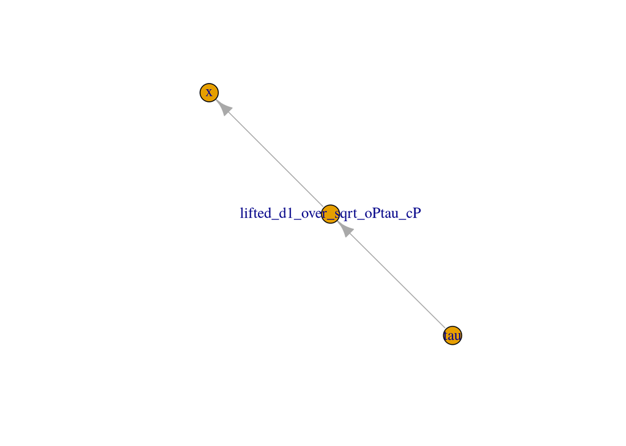

```r
plot(m1$getGraph())
```

```r
m1$getNodeNames()
```

```
## [1] "tau"                          "lifted_d1_over_sqrt_oPtau_cP"
## [3] "x"
```

The node `lifted_d1_over_sqrt_oPtau_cP` has been inserted between `tau` and `x`. The resulting model would equivalently have been created by this BUGS code:

```r
nimbleCode({
    tau ~ dunif(0, 100)
    lifted_d1_over_sqrt_oPtau_cP <- 1/sqrt(tau)
    x ~ dnorm(0, sd = lifted_d1_over_sqrt_oPtau_cP) # override and make 2nd arg the SD
})
```

NIMBLE has *lifted* the calculation of standard deviation from precision so that it is part of the model’s graph. Therefore *you will make a mistake if you assume that the dependencies of `tau` include only `x`*:

```r
m1$tau <- 3
m1$x <- 1
m1$calculate(c('tau','x')) ## Wrong: the lifted node is being neglected
```

```
## [1] NA
```

The correct way to do this is with model-generic programming:

```r
m1$getDependencies('tau')
```

```
## [1] "tau"                          "lifted_d1_over_sqrt_oPtau_cP"
## [3] "x"
```

```r
m1$calculate( m1$getDependencies('tau') )
```

```
## [1] -6.474803
```